# Door-to-Door Waste Collection: a difference-in-difference analysis.

# Introduction

Separate waste collection is a key component in sustainable waste management.

Studying the impact of door-to-door collection can offer insights into changes in citizen behavior regarding waste management.

Door-to-door collection can have significant implications for operational costs and the economic efficiency of the waste management system. Understanding if this practice leads to greater efficiency or long-term cost reduction can justify initial investments and guide budget decisions.

On the other side, it can also influence social cohesion and community sense, as it often requires greater collaboration and participation from residents. Studying this aspect can reveal positive effects on civic engagement and collective responsibility.

My colleagues [Andrea Tononi](https://www.linkedin.com/in/andrea-tononi-89783b253/) and [Matteo Ricca](https://www.linkedin.com/in/matteo-ricca/) and I developed a DID analysis to understand benefits and their extence of the introduction of door-to door collection as methodology of separate waste management.

“What is the impact of the introduction of door-to-door separate waste collection on the overall rate of separate waste collection in various municipality in Northern Italy?”

In 2021, slightly more than 73% of households reported being served by door-to-door waste collection (up from 66% in 2018). The average level of satisfaction with the service has been good and stable in recent years.

## Datasets used

To perform our analysis we manually created a dataset using ISPRA and Legambiente 2024 report data. The clusterization is at municipality level. The data from the province of each municipality has not been taken in consideration. This is because the policy is introduced at this level, it is not mandatory that in the same province all the municipality use door-to-door collection for separate waste management. This ensure the compatibility between population: with other level of clusterization the differences may create a selection bias.

Is important to underline that our collection of data starts from 2010. Cities such as Bergamo which introduced the policy before that year are assessed symply by starting from an higher value in year_ind variable.

In order to evaluate performance over time we introduced a variable for the policy-start date. Dates has been extracted from web research and municipality legislation documents.

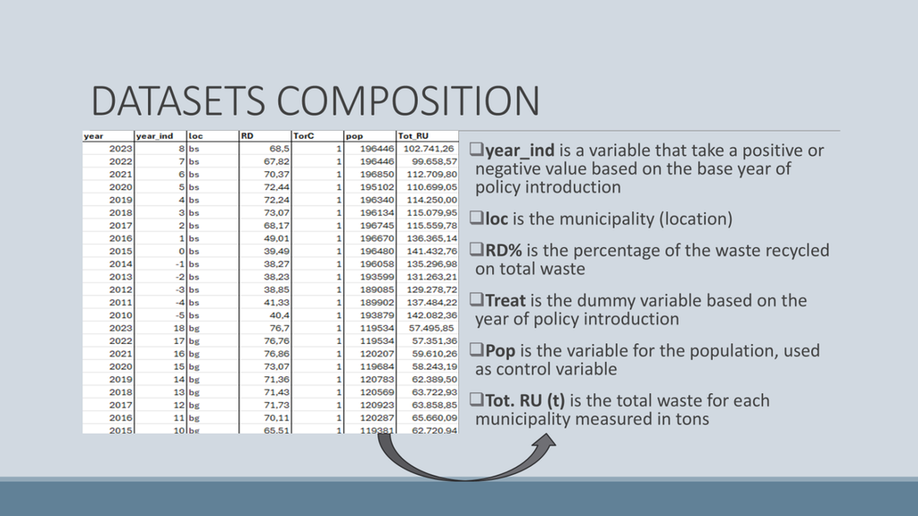

**Which cities as been taken into analysis?**

As already said only municipalities has been taken in consideration. A difference-in-difference approach, as many others impact evaluations methods, requires a treatment group (in our case the group of cities using door-to-door approach) and a control group (cities that have never introduced it).

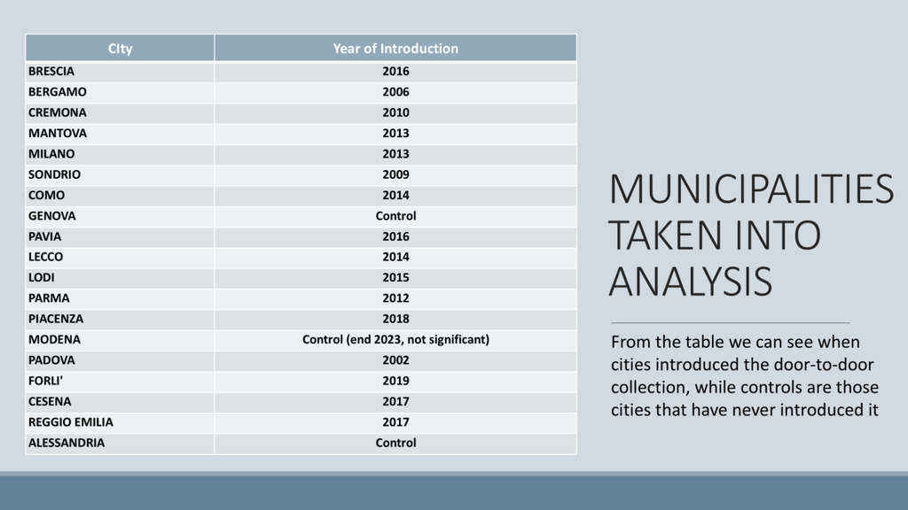